# Análisis de datos ómicos PEC2 Análisis RNA-seq

María Ramírez García

18/05/2025

# 1 Exploración de expresión génica diferencial en COVID-19

El análisis de perfiles de expresión génica permite entender mejor cómo responde nuestro organismo frente a distintas infecciones. En este trabajo, se utiliza información obtenida por McClain et al., quienes realizaron secuenciación de ARN en sangre periférica de pacientes con COVID-19, neumonía bacteriana, influenza, IRA (infección respiratoria aguda) y personas sanas. A partir de estos datos, se lleva a cabo un estudio de expresión diferencial utilizando R y Bioconductor, enfocándonos en identificar genes que cambian significativamente su expresión en cada grupo. Para el análisis se filtran los datos, trabajando con una muestra de individuos con COVID-19, neumonía bacteriana y sanos, se explora su distribución y agrupamiento según su perfil transcripcional, además de un estudio de expresión diferencial y de sobrerepresentación Este enfoque busca aportar nuevas pistas sobre biomarcadores útiles para el diagnóstico diferencial de infecciones respiratorias agudas.

# 2 Objetivos del análisis.

A continuación, se plantean los objetivos específicos que guían este análisis de expresión diferencial:

- Analizar la expresión génica diferencial entre pacientes con COVID-19, neumonía bacteriana y sujetos sanos.
- Visualizar la distribución y agrupación de muestras según el perfil transcripcional.
- Comparar los genes con expresión diferencial en COVID-19 vs. sanos y neumonía bacteriana vs. sanos, identificando biomarcadores comunes y específicos.
- Relacionar los genes con expresión diferencial en COVID-19 con procesos biológicos.

# 3 Datos para el análisis

## 3.1 Preparación de los datos

Desde la página de GEO a través del identificador GSE161731, se descargaron manualmente los archivos GSE161731_counts.csv.gz y GSE161731_key.csv.gz, que contienen la matriz de recuentos de expresión génica y los metadatos de las muestras, respectivamente. Ambos archivos se cargaron en R y se crearon dos objetos *counts* y *metadata* con el contenido de cada archivo, para la construcción de un objeto SummarizedExperiment, el cual requiere información en común para vincular correctamente las matrices de datos. Al explorar los datos se observó que, en los identificadores de muestra, hay pequeñas diferencias de formato: en la matriz de conteos algunos nombres comenzaban con una “X” y los guiones (“-”) estaban reemplazados por puntos (“.”). Se realizaron las modificaciones necesarias eliminando las “X” iniciales y reemplazando los puntos por guiones, de forma que los identificadores de las muestras quedaron idénticos en ambos objetos. Finalmente se eliminan los registros de *count* que no coinciden con *metadata* permitiendo así identificar y conservar únicamente las muestras en común.

Posteriormente, se ajustaron los tipos de datos de las variables contenidas en el metadata. La mayoría se encontraban como carácter, por lo que se convirtieron a factor.

En el caso de la variable edad, antes de transformarla a tipo numérico, se reemplazaron los valores “>89” por “90” y los “<1” por “0”, evitando de esta forma la generación de valores NA y permitiendo tratarla como una variable continua en los análisis posteriores. La edad, puede representar un posible factor confusor, por lo que se tendra en cuenta en los modelos de análisis que se realizaran más adelante, esta puede modular la respuesta inmune y, por ende, alterar los perfiles transcripcionales. Al tratar la edad como variable numérica continua, pueden surgir problemas de colinealidad o errores de convergencia en ciertos modelos. Convertirla a factor podría sobreajustar al aumentar el número de parámetros, y escalarla facilitaría la convergencia, pero podría perder efectos no lineales o diferencias importantes entre rangos de edad.

Como estrategia equilibrada, se decidió conservar la variable edad en formato numérico y, de forma complementaria, crear una nueva variable categórica que agrupa los sujetos en intervalos de edad predefinidos. Esta decisión permite comparar resultados utilizando ambas versiones y explorar su influencia como factor de confusión o modificador en los análisis de expresión diferencial y visualizaciones multivariadas.

Finalmente, se prepararon los objetos correspondientes para colData (metadata) y assays (counts), y se añadieron las coordenadas génicas a rowData utilizando el paquete EnsDb.Hsapiens.v86. Para ello, se descargó la base completa de genes humanos y se seleccionaron únicamente aquellos presentes en la matriz de recuentos. Con todos estos objetos listos, se construyó el objeto SummarizedExperiment, integrando la matriz de recuentos, la información de las muestras y los datos asociados a los genes.

```r
mySE <- SummarizedExperiment(assays = list(counts = as.matrix(counts_fil)), colData = metadata,
    rowRanges = genes_fil)
show(mySE)
```

```
class: RangedSummarizedExperiment
dim: 57602 195
metadata(0):
assays(1): counts
rownames(57602): ENSG00000223972 ENSG00000227232 ... ENSG00000277475
  ENSG00000268674
rowData names(6): gene_id gene_name ... symbol entrezid
colnames(195): 94189 DU09-03S0000604 ... 105847 105848
colData names(8): subject_id age ... hospitalized batch
```

Antes de continuar con el análisis, se realizó una limpieza y ajuste del objeto SummarizedExperiment (mySE). En primer lugar, se verificó la existencia de individuos duplicados en colData y, tras confirmar su presencia, se procedió a eliminar las duplicaciones, conservando únicamente la primera entrada de cada caso como criterio de selección. Como resultado, el número de muestras se redujo de 195 a 152.

Posteriormente, se exploró nuevamente colData para comprobar la correcta tipificación de las variables, observando que gender y cohort se encuentran como factores, y age como variable numérica, de acuerdo con los ajustes realizados previamente. Además, se realizaron modificaciones en las variables categóricas race y cohort, sustituyendo caracteres que podrían generar inconvenientes durante el análisis en R (como espacios en blanco, guiones o barras) por el carácter “_”.

Para definir las cohortes de interés, se visualizó la distribución de muestras en cada grupo disponible y, a continuación, se seleccionaron las muestras correspondientes a COVID19, Bacterial y Healthy para los análisis posteriores. Finalmente, tras realizar estas depuraciones, se seleccionaron 75 muestras de forma aleatoria utilizando una semilla de aleatoriedad establecida, garantizando así la reproducibilidad del análisis.

```r
show(mySE)
```

```
class: RangedSummarizedExperiment
dim: 57602 152
metadata(0):
assays(1): counts
rownames(57602): ENSG00000223972 ENSG00000227232 ... ENSG00000277475
  ENSG00000268674
rowData names(6): gene_id gene_name ... symbol entrezid
colnames(152): 94189 DU09-03S0000604 ... 105847 105848
colData names(8): subject_id age ... hospitalized batch
```

```r
str(colData(mySE))
```

```
Formal class 'DFrame' [package "S4Vectors"] with 6 slots
  ..@ rownames       : chr [1:152] "94189" "DU09-03S0000604" "DU09-03S0000611" "105920" ...
  ..@ nrows          : int 152
  ..@ elementType    : chr "ANY"
  ..@ elementMetadata: NULL
  ..@ metadata       : list()
  ..@ listData       :List of 8
  .. ..$ subject_id      : chr [1:152] "A1BD46" "44DF6B" "658A11" "61DE97" ...
  .. ..$ age             : num [1:152] 57 19 14 21 50 39 23 27 25 60 ...
  .. ..$ gender          : Factor w/ 2 levels "Female","Male": 1 2 2 1 1 1 1 2 1 2 ...
  .. ..$ race            : Factor w/ 7 levels "American Indian/Alaska Native",..: 3 3 7 7 3 3 3 3 3 7 ...
  .. ..$ cohort          : Factor w/ 5 levels "Bacterial","CoV other",..: 1 5 5 5 5 5 5 2 2 3 ...
  .. ..$ time_since_onset: Factor w/ 3 levels "early","late",..: NA NA NA NA NA NA NA NA NA 1 ...
  .. ..$ hospitalized    : Factor w/ 2 levels "No","Yes": NA NA NA NA NA NA NA NA NA 1 ...
  .. ..$ batch           : Factor w/ 2 levels "1","2": 1 2 2 1 1 1 1 1 1 1 ...
```

```r
# Visualización de cohortes
table(colData(mySE)$cohort)
```

```
Bacterial CoV_other  COVID_19   healthy Influenza
       23        48        46        18        17
```

```r
# Selección de COVID19, Bacterial y healthy.
mySE <- mySE[, colData(mySE)$cohort %in% c("COVID_19", "Bacterial", "healthy")]
```

```r
# Verificar los resultados
mySE
```

[output not shown]

```r
table(colData(mySE)$cohort)
```

```
Bacterial CoV_other  COVID_19   healthy Influenza
       19         0        41        15         0
```

## 3.2 Preprocesado y normalización de datos

Tras preparar los datos para comenzar el análisis y revisar que se han efectuado los cambios necesarios, se realiza el preprocesado inicial de los datos y su normalización.

Los genes con recuentos muy bajos en todas las librerías aportan poco valor al análisis diferencial e interfieren con algunas de las aproximaciones estadísticas. Por ello los genes se filtran según la expresión, eliminando aquellos con una expresión muy baja. Antes de filtrar se estandarizan los contajes basándose en el tamaño de la librería. Para ello se normalizan los contajes brutos para las diferentes profundidades de secuenciación para cada muestra. Esta se lleva a cabo con el paquete *edgerR* y su función *cpm()*, posteriormente se guardan los valores CPM (recuento por millón) obtenidos, en un nuevo *assay* (CPM) del *mySE*.

```r
# Filtrar los genes
triaje <- counts_CPM > 0.5  # Matriz booleana con TRUE donde CPM > 0.5
triaje_genes <- rowSums(triaje) >= 2  # Genes con al menos 2 muestras con CPM > 0.5

# Aplica el filtraje al SummarizedExperiment mySE y guarda uno nuevo con los
# datos filtrados
mySE_filt <- mySE[triaje_genes, ]

# Verificar número de genes tras el filtrado
dim(assay(mySE, "CPM"))  # Dimensiones sin filtrar genes
```

```
[1] 57602    75
```

```r
dim(assay(mySE_filt, "CPM"))  # Dimensiones con los genes filtrados
```

```
[1] 24795    75
```

Se puede observar que después de descartar los genes con baja expresión su número se reduce considerablemente, sin filtrar encontrábamos 57.602 genes secuenciados y tras el filtrado se han obtenido 24.795 genes.

Para trabajar los datos de manera más eficiente, se crea un objeto de clase específica para gestionar datos complejos, *DGEList*, del paquete *edgeR*. Una de las ventajas de manejar este objeto es usar la función *calcNormFactors* para calcular los factores de normalización entre librerías. De esta forma los datos siguen una normalización TMM que elimina los sesgos de comparación entre librerías.

# 4 Análisis exploratorio

Tras descartar los genes con baja expresión se realizan gráficos exploratorios para ver la distribución de los datos, su calidad y si presentan algún problema.

## 4.1 Distribución de las mmuestras

Se realizaron dos boxplots para explorar la distribución de los niveles de expresión génica en las muestras antes y después del proceso de normalización. Dado que los datos de conteo de secuenciación no siguen una distribución normal, se aplicó una transformación logarítmica (log2 CPM) para facilitar la visualización y comparación de las muestras.

En el primer gráfico, se representan los valores de expresión sin normalizar. Se puede observar cierta heterogeneidad en las medianas y rangos intercuartílicos entre muestras y cohortes, lo cual es esperable debido a las diferencias en la profundidad de secuenciación y composición de las bibliotecas.

Para facilitar la identificación de cada cohorte, las muestras se colorearon según su grupo de pertenencia: COVID-19 (azul), Bacterial (rojo) y Healthy (verde claro).

La línea horizontal azul indica la mediana global de expresión, sirviendo como referencia para detectar muestras con distribuciones atípicas o desviadas.

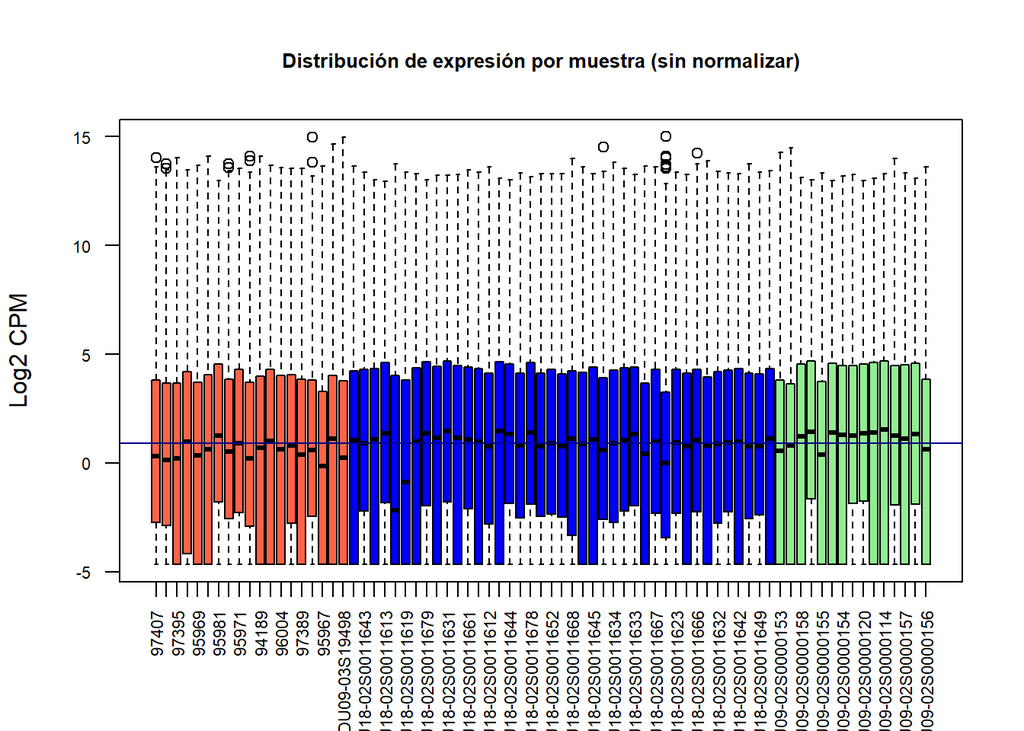

*Figura1: Boxplot para la distribución de muestras sin normalizar.*

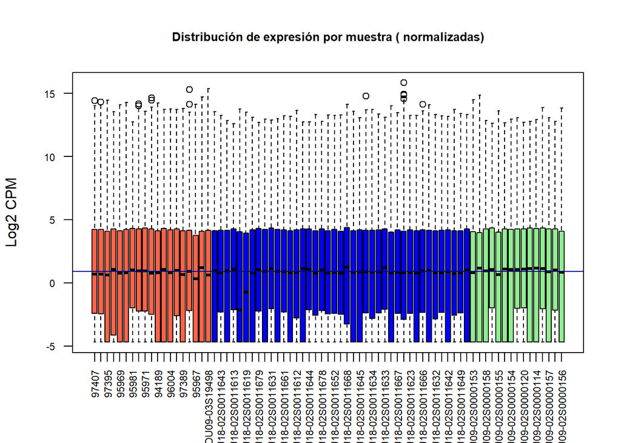

*Figura2: Boxplot para la distribución de muestras normalizadas.*

## 4.2 Comparación entre muestras

Con la finalidad de comparar las muestras entre sí, se calcula la matriz de distancia de las muestras, utilizando la función *dist* y posteriormente representando la distancia mediante agrupación jerárquica con un dendrograma y un heatmap.

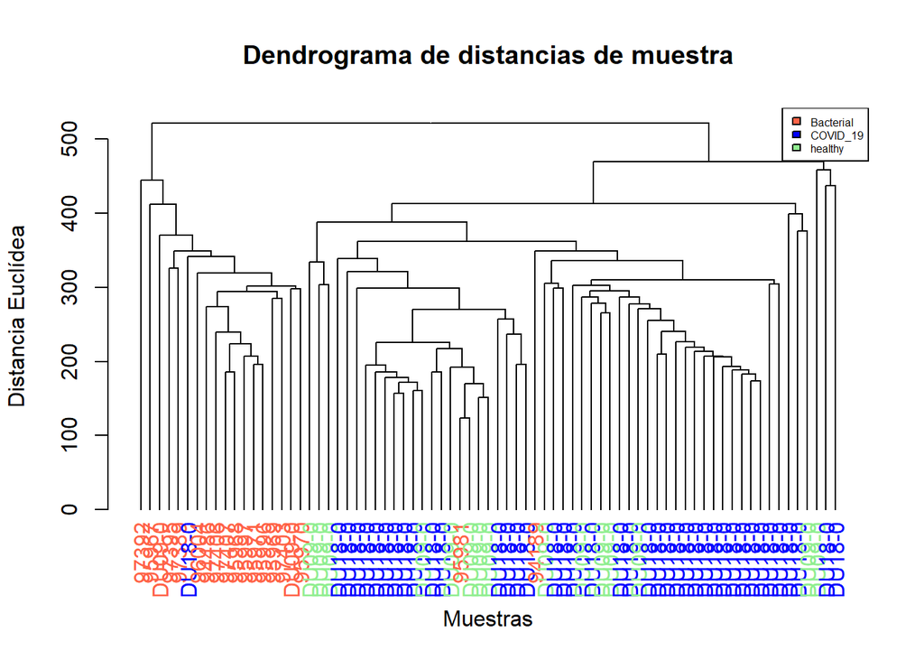

*Figura 3: Agrupamiento jerárquico de las muestras según la matriz de distancias. Nota: Para mejorar la visualización, los nombres de las muestras se han reducido.*

En la *figura 3* se observa que el grupo de individuos con neumonía bacteriana aparece claramente separado del resto, formando un bloque diferenciado salvo por dos muestras que quedan algo desplazadas. Por el contrario, los individuos sanos y los pacientes con COVID-19 no muestran una separación tan marcada entre ellos, distribuyéndose de forma más mezclada.

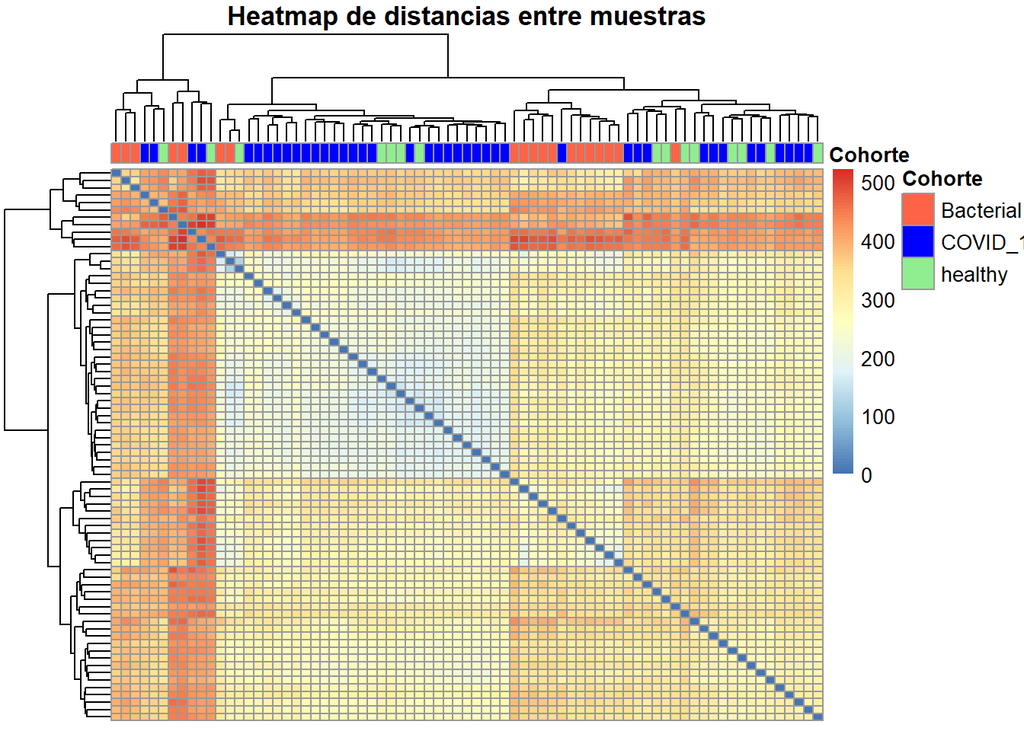

*Figura 4: Heatmap de distancias*

Tanto en lel denograma como en el heatmap se observa que las muestras de neumonía bacteriana se diferencian claramente del resto, mientras que las de COVID-19 y healthy presentan perfiles de expresión muy similares entre sí.

Para complementar los gráficos anteriores y comprobar si los agrupamientos de muestras son similares a los mostrados por el heatmaps y el dendrograma, se realiza un MDS (Multidimensional Scaling). Con este se puede observar en un espacio de dimensiones reducidas las relaciones de similitud entre las muestras, además se pueden detectar outliers o posible efecto batch. Para este grafico se utiliza *limma::plotMDS*.

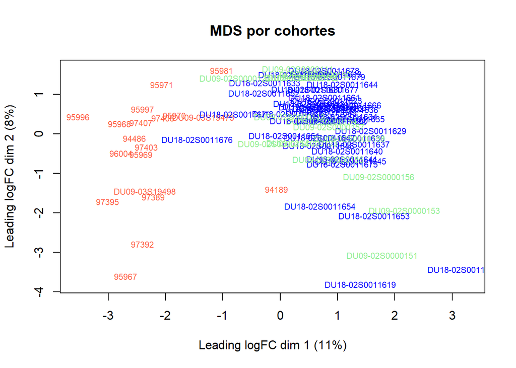

*Figura 5: MDS por cohortes. Rojo: neumonia bacteriana; azul: COVID 19; verde: individuos sanos.*

En el MDS destacan varios puntos que se apartan del núcleo de su cohorte y pueden considerarse outliers: dentro de la cohorte bacteriana sobresalen las muestras 95967, 97392 y 95996, todas desplazadas respecto al resto del grupo; en COVID-19 se alejan DU18-02S0011654, DU18-02S0011619 y DU18-02S0011639, situadas por debajo o a la derecha de la agrupación principal; y en healthy se dispersan las muestras DU09-02S000151, 153 y 156, ubicadas ligeramente por debajo del conjunto central.

```
           Muestra Batch   Color
1  DU09-02S0000153     1 #FF0000
2  DU18-02S0011653     1 #FF0000
3            97407     1 #FF0000
4  DU09-02S0000151     1 #FF0000
5            95968     1 #FF0000
6            97395     1 #FF0000
7  DU18-02S0011643     1 #FF0000
8    DU09-03S19475     1 #FF0000
9  DU18-02S0011654     1 #00FFFF
10 DU18-02S0011613     1 #FF0000
11 DU18-02S0011639     2 #FF0000
12 DU18-02S0011619     1 #FF0000
13 DU18-02S0011647     1 #FF0000
14           95969     1 #FF0000
15 DU18-02S0011679     1 #FF0000
16 DU18-02S0011630     1 #FF0000
17 DU18-02S0011631     2 #FF0000
18 DU09-02S0000158     1 #FF0000
19           97403     1 #FF0000
20 DU09-02S0000111     1 #FF0000
21 DU18-02S0011629     1 #FF0000
22 DU09-02S0000155     1 #FF0000
23 DU09-02S0000103     1 #FF0000
24           95981     1 #00FFFF
25 DU18-02S0011661     1 #FF0000
 [ reached 'max' / getOption("max.print") -- omitted 50 rows ]
```

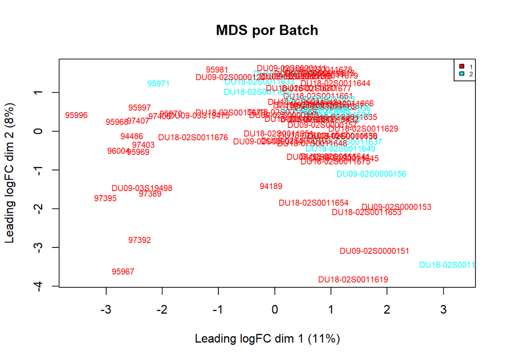

*Figura 6: MDS según batch.*

El análisis del posible efecto batch mostró que las muestras bacterianas más alejadas (95967, 97392, 94189) pertenecen al mismo lote que el resto de su cohorte, por lo que su distancia no se explica por el batch. En COVID-19 y healthy los puntos no se agrupan ni por cohorte ni por lote, de modo que el efecto batch tampoco justifica la dispersión observada. Se proponen como outliers visuales 95967, 97392 y 94189 (bacterial), DU18-02S0011619 y DU18-02S0011639 (COVID-19) y DU09-02S0000151 (healthy), aunque sería necesario fijar criterios objetivos de exclusión. En conjunto, los perfiles de neumonía bacteriana se distinguen claramente de los otros dos grupos, mientras que COVID-19 y healthy no muestran una separación definida.

```r
# Posibles outliers
outliers <- c("95967", "97392", "94189", "DU18-02S0011619", "DU18-02S0011639", "DU09-02S0000151")
# Elimina outliers del SummarizedExperiment
mySE_filt <- mySE_filt[, !colnames(mySE_filt) %in% outliers]
dim(assay(mySE_filt, "CPM"))  # Comprobbar que eliminó las 6 muestras (75-6=69)
```

```
[1] 24795    69
```

# 5 Análisis de expresión génica diferencial

En *DESeq2*, a diferencia de otros paquetes como *lima*, no se crea una matriz de contrastes explícita previa al análisis. En su lugar, se ajusta un modelo lineal generalizado negativo binomial mediante una fórmula de diseño, y posteriormente se definen los contrastes al extraer los resultados con la función *results()*.

```r
# Extrar las martiz de diseño
matriz_dis <- model.matrix(design(dds), data = colData(dds))  # Extrae la fórmula con design(dds) y toma los datos de colData(dds).
```

Para estudiar la expresión diferencial se plantean dos contrastes principales: **Bacterial vs Healthy** y **COVID-19 vs Healthy**. De este modo se identifican los genes cuyo nivel de expresión varía específicamente en los individuos con neumonía bacteriana, por un lado, y en los pacientes con COVID-19, por otro, siempre frente al mismo referente de sujetos sanos.

```r
# En DESeq2 los contrastes se especifican directamente al extraer los
# resultados con results(), no se crean matrices explicitas Bacterial vs
# healthy
res_bacterial <- results(dds, contrast = c("cohort", "Bacterial", "healthy"))
head(res_bacterial)  # Visualizar los resultados de los primeros genes
```

```
log2 fold change (MLE): cohort Bacterial vs healthy
Wald test p-value: cohort Bacterial vs healthy
DataFrame with 6 rows and 6 columns
                  baseMean log2FoldChange     lfcSE      stat     pvalue
                 <numeric>      <numeric> <numeric> <numeric>  <numeric>
ENSG00000223972   23.73623      -3.266450  1.317283 -2.479686 0.01314981
ENSG00000227232  340.10759      -0.766453  0.510806 -1.500478 0.13349052
ENSG00000278267   54.36523      -0.857278  0.880681 -0.973426 0.33034143
ENSG00000238009  173.96394       2.274069  0.742689  3.061939 0.00219908
ENSG00000233750    4.84812       2.659733  2.201844  1.207957 0.22706368
ENSG00000268903 4250.42595       1.249713  0.402305  3.106380 0.00189393
                      padj
                 <numeric>
ENSG00000223972 0.04209906
ENSG00000227232 0.27054854
ENSG00000278267 0.51571584
ENSG00000238009 0.00914082
ENSG00000233750         NA
ENSG00000268903 0.00804760
```

```r
# COVID-19 vs healthy
res_covid <- results(dds, contrast = c("cohort", "COVID_19", "healthy"))
head(res_covid)  #Visualizar los resultados de los primeros genes
```

```
log2 fold change (MLE): cohort COVID_19 vs healthy
Wald test p-value: cohort COVID 19 vs healthy
DataFrame with 6 rows and 6 columns
                  baseMean log2FoldChange     lfcSE      stat    pvalue
                 <numeric>      <numeric> <numeric> <numeric> <numeric>
ENSG00000223972   23.73623      0.2450903  0.844408  0.290251 0.7716242
ENSG00000227232  340.10759      0.0691621  0.340979  0.202834 0.8392648
ENSG00000278267   54.36523     -0.1693226  0.587318 -0.288298 0.7731187
ENSG00000238009  173.96394     -0.8676487  0.496741 -1.746683 0.0806923
ENSG00000233750    4.84812     -1.8176125  1.463531 -1.241936 0.2142600
ENSG00000268903 4250.42595     -0.2545827  0.268484 -0.948221 0.3430167
                     padj
                <numeric>
ENSG00000223972        NA
ENSG00000227232  0.940056
ENSG00000278267  0.912427
ENSG00000238009  0.280627
ENSG00000233750        NA
ENSG00000268903  0.629695
```

```r
# coeficientes para construir los contrastes
resultsNames(dds)
```

```
 [1] "Intercept"
 [2] "batch_2_vs_1"
 [3] "race_Black_African_American_vs_Asian"
 [4] "race_Native_Hawaiian_Pacific_Islander_vs_Asian"
 [5] "race_Other_More_than_one_race_vs_Asian"
 [6] "race_Unknown_Not_reported_vs_Asian"
 [7] "race_White_vs_Asian"
 [8] "gender_Male_vs_Female"
 [9] "cohort_Bacterial_vs_healthy"
[10] "cohort_COVID_19_vs_healthy"
```

Se aplicó un filtrado por criterios de significación, seleccionando genes con un valor ajustado de p inferior a 0.05 y una diferencia absoluta en log2FoldChange mayor a 1.5, lo que equivale a una diferencia de expresión de al menos 2.8 veces entre grupos. Este doble umbral permite garantizar que los genes seleccionados no solo presentan diferencias estadísticamente significativas, sino que estas son además biológicamente relevantes.

```r
# Filtra valores con el p-valor ajustado <0.05 & Filtra por una diferencia de
# expresión de al menos 2.8 veces entre los grupos.

# Filtrar resultados para Bacterial vs healthy
res_bacterial_sig <- res_bacterial[which(res_bacterial$padj < 0.05 & abs(res_bacterial$log2FoldChange) >
    1.5), ]
head(res_bacterial_sig)
```

```
log2 fold change (MLE): cohort Bacterial vs healthy
Wald test p-value: cohort Bacterial vs healthy
DataFrame with 6 rows and 6 columns
                 baseMean log2FoldChange     lfcSE      stat      pvalue
                <numeric>      <numeric> <numeric> <numeric>   <numeric>
ENSG00000223972   23.7362       -3.26645  1.317283  -2.47969 1.31498e-02
ENSG00000238009  173.9639        2.27407  0.742689   3.06194 2.19908e-03
ENSG00000228463  149.5665        2.66710  0.850888   3.13449 1.72156e-03
ENSG00000237094  120.7863        2.16576  0.576671   3.75562 1.72913e-04
ENSG00000225972 1571.2262       -2.19088  0.777393  -2.81824 4.82873e-03
ENSG00000188290  400.9422       -3.37573  0.698224  -4.83473 1.33324e-06
                       padj
                  <numeric>
ENSG00000223972 4.20991e-02
ENSG00000238009 9.14082e-03
ENSG00000228463 7.40044e-03
ENSG00000237094 1.01699e-03
ENSG00000225972 1.79315e-02
ENSG00000188290 1.40111e-05
```

```r
nrow(res_bacterial_sig)  # Número de genes significativos y con alto cambio
```

```
[1] 2454
```

```r
# Filtrar resultados para COVID-19 vs healthy
res_covid_sig <- res_covid[which(res_covid$padj < 0.05 & abs(res_covid$log2FoldChange) >
    1.5), ]
head(res_covid_sig)
```

```
log2 fold change (MLE): cohort COVID_19 vs healthy
Wald test p-value: cohort COVID 19 vs healthy
DataFrame with 6 rows and 6 columns
                  baseMean log2FoldChange     lfcSE      stat      pvalue
                 <numeric>      <numeric> <numeric> <numeric>   <numeric>
ENSG00000078900    59.8678        2.16089  0.741067   2.91591 3.54650e-03
ENSG00000200087    83.2896       -2.83599  0.694723  -4.08218 4.46151e-05
ENSG00000117399   400.8525        2.01407  0.490022   4.11015 3.95397e-05
ENSG00000137970   376.9131       -1.90837  0.409675  -4.65826 3.18894e-06
ENSG00000244716    37.8530       -2.35876  0.511585  -4.61070 4.01313e-06
ENSG00000177954 23845.0349       -1.77329  0.348271  -5.09170 3.54860e-07
                       padj
                  <numeric>
ENSG00000078900 4.03535e-02
ENSG00000200087 2.01246e-03
ENSG00000117399 1.84659e-03
ENSG00000137970 2.92919e-04
ENSG00000244716 3.53622e-04
ENSG00000177954 6.11166e-05
```

```r
nrow(res_covid_sig)  # Número de genes significativos y con alto cambio
```

```
[1] 202
```

## 5.1 Contrastes para los perfiles con neumonía bacteriana y COVID-19

Tras realizar el análisis diferencial de expresión y aplicar el filtrado de genes se seleccionan 2.454 genes para el perfil de neumonía bacteriana y 202 genes para COVID-19, ambos en comparación con individuos sanos.

Para comparar los resultados de ambos contrastes (Bacterial vs healthy y COVID19 vs healthy). Se utiliza un diagrama de Venn.

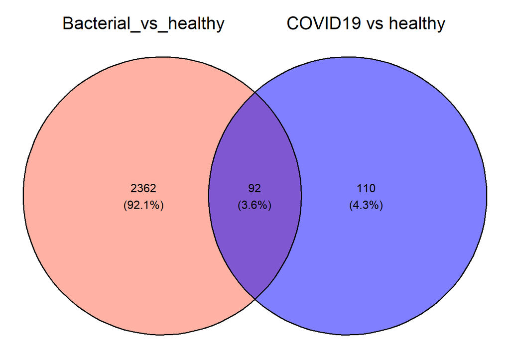

```r
# Diagrama de Venn
library("ggvenn")

# Crea una lista con los genes diferencialmente expresados en cada contraste
Venn <- list(Bacterial_vs_healthy = c(rownames(res_bacterial_sig)), `COVID19 vs healthy` = c(rownames(res_covid_sig)))

# Generar el diagrama de Venn con los conjuntos definidos
ggvenn(Venn, fill_color = c("tomato", "blue"), stroke_size = 0.6, set_name_size = 6)
```

*Figura 7: Diagrama de Venn. Contraste para Bacterial vs Healthy y COVID-19 vs Healthy*

La intersección del diagrama de Venn muestra 92 genes que se regulan de forma diferencial tanto en pacientes con neumonía bacteriana como en los afectados por COVID-19. El contraste Bacterial vs Healthy aporta 2 362 genes exclusivos, mientras que COVID-19 vs Healthy presenta 110 genes propios. Que exista un subconjunto común es esperable desde el punto de vista biológico: ambas condiciones implican infecciones respiratorias agudas y activan rutas inmunitarias compartidas.

# 6 Análisis de sobrerepresentación

```
------------------------- topGOdata object -------------------------

 Description:
   -

 Ontology:
   -  BP

 24795 available genes (all genes from the array):
   - symbol:  ENSG00000223972 ENSG00000227232 ENSG00000278267 ENSG00000238009 ENSG00000233750  ...
   - score :  0.2450903455652 0.06916210900181 -0.1693225601662 -0.8676486749935 -1.817612547674  ...
   - 0  significant genes.

 14226 feasible genes (genes that can be used in the analysis):
   - symbol:  ENSG00000229344 ENSG00000187634 ENSG00000188976 ENSG00000187961 ENSG00000187583  ...
   - score :  -0.005684047223555 -0.6635289641752 0.2146024926987 -0.2345833040169 0.1955578553404  ...
   - 0  significant genes.

 GO graph (nodes with at least  1  genes):
   - a graph with directed edges
   - number of nodes = 14837
   - number of edges = 32982

------------------------- topGOdata object -------------------------
```

```
[1] 202
```

Al no poder ejecutar un enriquecimiento GO efectivo, se pierde la oportunidad de vincular los cambios de expresión observados con procesos biológicos concretos, jerarquizar vías relevantes y generar hipótesis funcionales sobre la respuesta al SARS‑CoV‑2

# 7 Discursión y Conclusiones

## 7.1 Discusión

Los resultados confirman que la neumonía bacteriana induce un cambio transcriptómico periférico mucho más marcado que COVID-19. La poca distancia observada entre los casos de COVID-19 y los individuos sanos indica que las muestras de COVID son heterogeneas. Para determinar mejor esas diferencias, convendría incorporar metadatos como tiempo desde síntomas o severidad en futuros modelos.

Mientras que los genes compartidos entre perfiles de expresión ayudan a entender las vías comunes de infecciones respiratorias. Los genes exclusivos de cada cohorte son candidatos a biomarcadores diferenciales que podrían mejorar la clasificación de infecciones respiratorias en la práctica clínica.

## 7.3 Limitación y problemas

- Dispersión de las muestras COVID-19 y healthy, dificulta detectar efectos sutiles.
- Tamaño de la muestra relativamente pequeño.
- A nivel del análisis de datos, se podría haber hecho un estudio más exhaustivo de las posibles variables confusoras. Con una mejor preparación y manipulación de los datos se podría haber realizado un buen estudio de sobreexpreión (no he podido anotar correctamente los genes en este paso)

# 8 Referencias

Repositorio: https://github.com/maria-r-g/Ramirez-Garcia-Maria-PEC2.git

Law C, Alhamdoosh M, Su S, Dong X, Tian L, Smyth G, Ritchie MR. RNAseq123: RNA-seq analysis is easy as 1-2-3 with limma, Glimma and edgeR [Internet]. Bioconductor; 2025 [citado 18 may 2025]. Disponible en: https://www.bioconductor.org/packages/release/workflows/html/RNAseq123.html

McClain MT, Constantine FJ, Henao R, Liu Y, Tsalik EL, Burke TW, et al. Dysregulated transcriptional responses to SARS-CoV-2 in the periphery. Nat Commun. 2021;12:1079. Disponible en: https://www.nature.com/articles/s41467-021-21289-y

NCBI GEO. GSE161731: Dysregulated transcriptional responses to SARS-CoV-2 in the periphery support novel diagnostic approaches [Internet]. Bethesda (MD): NCBI; 2020 [consultado 18 may 2025]. Disponible en: https://www.ncbi.nlm.nih.gov/geo/query/acc.cgi?acc=GSE161731

Love MI, Anders S, Huber W. Analyzing RNA-seq data with DESeq2 [Internet]. Bioconductor; 2025 [citado 18 may 2025]. Disponible en: https://bioconductor.org/packages/release/bioc/vignettes/DESeq2/inst/doc/DESeq2.html